# Index

Bela Szlovicsak

2023-06-14

```r
# Get the Data

# Read in with tidytuesdayR package
# This loads the readme and all the datasets for the week of interest


tuesdata <- tidytuesdayR::tt_load('2022-01-25')
```

```
## --- Compiling #TidyTuesday Information for 2022-01-25 ----
```

```
## --- There are 2 files available ---
```

```
## --- Starting Download ---
```

```
## --- Download complete ---
```

```r
ratings <- tuesdata$ratings
details <- tuesdata$details
```

# EDA

Explore the Boardgames dataset, visualize some possible interesting variables. The goal to estimate will probably be avarage rating

```r
str(ratings)
```

```
## spc_tbl_ [21,831 × 10] (S3: spec_tbl_df/tbl_df/tbl/data.frame)
##  $ num          : num [1:21831] 105 189 428 72 103 191 100 3 15 35 ...
##  $ id           : num [1:21831] 30549 822 13 68448 36218 ...
##  $ name         : chr [1:21831] "Pandemic" "Carcassonne" "Catan" "7 Wonders" ...
##  $ year         : num [1:21831] 2008 2000 1995 2010 2008 ...
##  $ rank         : num [1:21831] 106 190 429 73 104 192 101 4 16 36 ...
##  $ average      : num [1:21831] 7.59 7.42 7.14 7.74 7.61 7.41 7.6 8.42 8.11 7.93 ...
##  $ bayes_average: num [1:21831] 7.49 7.31 6.97 7.63 7.5 ...
##  $ users_rated  : num [1:21831] 108975 108738 108024 89982 81561 ...
##  $ url          : chr [1:21831] "/boardgame/30549/pandemic" "/boardgame/822/carcassonne" "/boardgame/13/catan" "/boardgame/68448/7-wonders" ...
##  $ thumbnail    : chr [1:21831] "https://cf.geekdo-images.com/S3ybV1LAp-8SnHIXLLjVqA__micro/img/S4tXI3Yo7BtqmBoKINLLVUFsaJ0=/fit-in/64x64/filter"| __truncated__ "https://cf.geekdo-images.com/okM0dq_bEXnbyQTOvHfwRA__micro/img/VfLoKzfk3xj26ArmDu55qZ4sysw=/fit-in/64x64/filter"| __truncated__ "https:…
##  - attr(*, "spec")=
##   .. cols(
##   ..   num = col_double(),
##   ..   id = col_double(),
##   ..   name = col_character(),
##   ..   year = col_double(),
##   ..   rank = col_double(),
##   ..   average = col_double(),
##   ..   bayes_average = col_double(),
##   ..   users_rated = col_double(),
##   ..   url = col_character(),
##   ..   thumbnail = col_character()
##   .. )
##  - attr(*, "problems")=<externalptr>
```

```r
str(details)
```

```
## spc_tbl_ [21,631 × 23] (S3: spec_tbl_df/tbl_df/tbl/data.frame)
##  $ num                    : num [1:21631] 0 1 2 3 4 5 6 7 8 9 ...
##  $ id                     : num [1:21631] 30549 822 13 68448 36218 ...
##  $ primary                : chr [1:21631] "Pandemic" "Carcassonne" "Catan" "7 Wonders" ...
##  $ description            : chr [1:21631] "In Pandemic, several virulent diseases have broken out simultaneously all over the world! The players are disea"| __truncated__ "Carcassonne is a tile-placement game in which the players draw and place a tile with a piece of southern French"| __truncated…
##  $ yearpublished          : num [1:21631] 2008 2000 1995 2010 2008 ...
##  $ minplayers             : num [1:21631] 2 2 3 2 2 2 2 1 2 1 ...
##  $ maxplayers             : num [1:21631] 4 5 4 7 4 5 8 5 2 5 ...
##  $ playingtime            : num [1:21631] 45 45 120 30 30 60 15 120 30 150 ...
##  $ minplaytime            : num [1:21631] 45 30 60 30 30 30 15 120 30 30 ...
##  $ maxplaytime            : num [1:21631] 45 45 120 30 30 60 15 120 30 150 ...
##  $ minage                 : num [1:21631] 8 7 10 10 13 8 14 12 10 12 ...
##  $ boardgamecategory      : chr [1:21631] "['Medical']" "['City Building', 'Medieval', 'Territory Building']" "['Economic', 'Negotiation']" "['Ancient', 'Card Game', 'City Building', 'Civilization', 'Economic']" ...
##  $ boardgamemechanic      : chr [1:21631] "['Action Points', 'Cooperative Game', 'Hand Management', 'Point to Point Movement', 'Set Collection', 'Trading'"| __truncated__ "['Area Majority / Influence', 'Map Addition', 'Tile Placement']" "['Dice Rolling', 'Hexagon Grid', 'Income', 'Modular Board',…
##  $ boardgamefamily        : chr [1:21631] "['Components: Map (Global Scale)', 'Components: Multi-Use Cards', 'Digital Implementations: Board Game Arena', "| __truncated__ "['Cities: Carcassonne (France)', 'Components: Meeples (Black)', 'Components: Meeples (Blue)', 'Components: Meep"| __truncated…
##  $ boardgameexpansion     : chr [1:21631] "['Pandemic: Gen Con 2016 Promos – Z-Force Team Member/Game Convention', 'Pandemic: In the Lab', 'Pandemic: On t"| __truncated__ "['20 Jahre Darmstadt Spielt', 'Apothecaries (fan expansion for Carcassonne)', 'Apothecaries and Tithes (fan exp"| __truncated…
##  $ boardgameimplementation: chr [1:21631] "['Pandemic Legacy: Season 0', 'Pandemic Legacy: Season 1', 'Pandemic Legacy: Season 2', 'Pandemic: Fall of Rome"| __truncated__ "['The Ark of the Covenant', 'Carcassonne für 2', 'Carcassonne Junior', 'Carcassonne: Amazonas', 'Carcassonne: D"| __truncated…
##  $ boardgamedesigner      : chr [1:21631] "['Matt Leacock']" "['Klaus-Jürgen Wrede']" "['Klaus Teuber']" "['Antoine Bauza']" ...
##  $ boardgameartist        : chr [1:21631] "['Josh Cappel', 'Christian Hanisch', 'Régis Moulun', 'Chris Quilliams', 'Tom Thiel']" "['Doris Matthäus', 'Anne Pätzke', 'Chris Quilliams', 'Klaus-Jürgen Wrede']" "['Volkan Baga', 'Tanja Donner', 'Pete Fenlon', 'Jason Hawkins', 'Michaela Kienle', 'Harald…
##  $ boardgamepublisher     : chr [1:21631] "['Z-Man Games', 'Albi', 'Asmodee', 'Asmodee Italia', 'Asterion Press', 'Bergsala Enigma (Enigma)', 'Brain Games"| __truncated__ "['Hans im Glück', '999 Games', 'Albi', 'Bard Centrum Gier', 'Bergsala Enigma (Enigma)', 'Brain Games', 'cutia.r"| __truncated…
##  $ owned                  : num [1:21631] 168364 161299 167733 120466 106956 ...
##  $ trading                : num [1:21631] 2508 1716 2018 1567 2009 ...
##  $ wanting                : num [1:21631] 625 582 485 1010 655 ...
##  $ wishing                : num [1:21631] 9344 7383 5890 12105 8621 ...
##  - attr(*, "spec")=
##   .. cols(
##   ..   num = col_double(),
##   ..   id = col_double(),
##   ..   primary = col_character(),
##   ..   description = col_character(),
##   ..   yearpublished = col_double(),
##   ..   minplayers = col_double(),
##   ..   maxplayers = col_double(),
##   ..   playingtime = col_double(),
##   ..   minplaytime = col_double(),
##   ..   maxplaytime = col_double(),
##   ..   minage = col_double(),
##   ..   boardgamecategory = col_character(),
##   ..   boardgamemechanic = col_character(),
##   ..   boardgamefamily = col_character(),
##   ..   boardgameexpansion = col_character(),
##   ..   boardgameimplementation = col_character(),
##   ..   boardgamedesigner = col_character(),
##   ..   boardgameartist = col_character(),
##   ..   boardgamepublisher = col_character(),
##   ..   owned = col_double(),
##   ..   trading = col_double(),
##   ..   wanting = col_double(),
##   ..   wishing = col_double()
##   .. )
##  - attr(*, "problems")=<externalptr>
```

This is a lot of detail. A whole bunch of variables will not be of interest, for example: url, thumbnail, description, num (not identical in the two dataframes), some of the playing time variables, Expansion (is not based on id, maybe if we transform it to an indicator variable it could be useful). I will check to other variables to see if there is anything interesting to observe. Currently we have a huge amount of boardgames, but some might have really low number of ratings. These I will filter out.

```r
summary(ratings)
```

```
##       num              id             name                year
##  Min.   :    0   Min.   :     1   Length:21831       Min.   :   0
##  1st Qu.: 5458   1st Qu.: 12308   Class :character   1st Qu.:2001
##  Median :10915   Median :104994   Mode  :character   Median :2011
##  Mean   :10915   Mean   :118145                      Mean   :1987
##  3rd Qu.:16372   3rd Qu.:207219                      3rd Qu.:2017
##  Max.   :21830   Max.   :350992                      Max.   :3500
##       rank          average      bayes_average    users_rated
##  Min.   :    1   Min.   :1.040   Min.   :0.000   Min.   :    30
##  1st Qu.: 5458   1st Qu.:5.830   1st Qu.:5.510   1st Qu.:    56
##  Median :10916   Median :6.450   Median :5.545   Median :   122
##  Mean   :10916   Mean   :6.417   Mean   :5.682   Mean   :   867
##  3rd Qu.:16374   3rd Qu.:7.040   3rd Qu.:5.674   3rd Qu.:   392
##  Max.   :21831   Max.   :9.570   Max.   :8.511   Max.   :108975
##      url             thumbnail
##  Length:21831       Length:21831
##  Class :character   Class :character
##  Mode  :character   Mode  :character
##
##
##
```

```r
ratings %>%
  filter(users_rated >= 100) %>%
  summary()
```

```
##       num              id             name                year
##  Min.   :    0   Min.   :     1   Length:12142       Min.   :   0
##  1st Qu.: 3035   1st Qu.: 12307   Class :character   1st Qu.:2003
##  Median : 6072   Median :113602   Mode  :character   Median :2012
##  Mean   : 7622   Mean   :117800                      Mean   :1998
##  3rd Qu.:10192   3rd Qu.:204734                      3rd Qu.:2017
##  Max.   :21829   Max.   :350736                      Max.   :3500
##       rank          average      bayes_average    users_rated
##  Min.   :    1   Min.   :1.160   Min.   :3.575   Min.   :   100.0
##  1st Qu.: 3036   1st Qu.:6.050   1st Qu.:5.552   1st Qu.:   168.0
##  Median : 6073   Median :6.590   Median :5.645   Median :   329.0
##  Mean   : 7623   Mean   :6.566   Mean   :5.814   Mean   :  1514.4
##  3rd Qu.:10193   3rd Qu.:7.130   3rd Qu.:5.909   3rd Qu.:   924.8
##  Max.   :21830   Max.   :9.290   Max.   :8.511   Max.   :108975.0
##      url             thumbnail
##  Length:12142       Length:12142
##  Class :character   Class :character
##  Mode  :character   Mode  :character
##
##
##
```

Filtering out games with less than a 100 ratings help this variable become more reliable, while we keep averages similar to the original. Regarding creation year: some games were made before the 90’s which is the beginning of the modern board game era, these games will be removed.

```r
bgames <- details %>%
  left_join(ratings, by = "id") %>%
  #Get rid of some unnecessary variables
  #Implementation only contains other names, family is not interesting either
  select(-c(num.x, primary, description, num.y, url, thumbnail,
            boardgamefamily, boardgameimplementation))
```

## Popular mechanics and categories

Get out popular mechanics and categories to see if their presence is significant

```r
#Keep popular mechanics in a vector for easier use later
pop_mechanic <- bgames %>%
  filter(users_rated >= 100, !is.na(boardgamemechanic)) %>%
  mutate(boardgamemechanic = str_extract_all(boardgamemechanic, "\'([^\']*)\'")) %>%
  unnest_longer(boardgamemechanic) %>%
  count(boardgamemechanic) %>%
  slice_max(order_by = n, n = 25) %>%
  pull(boardgamemechanic)
pop_mechanic
```

```
##  [1] "'Dice Rolling'"                  "'Hand Management'"
##  [3] "'Set Collection'"                "'Variable Player Powers'"
##  [5] "'Card Drafting'"                 "'Modular Board'"
##  [7] "'Tile Placement'"                "'Area Majority / Influence'"
##  [9] "'Simulation'"                    "'Hexagon Grid'"
## [11] "'Cooperative Game'"              "'Grid Movement'"
## [13] "'Action Points'"                 "'Simultaneous Action Selection'"
## [15] "'Area Movement'"                 "'Auction/Bidding'"
## [17] "'Solo / Solitaire Game'"         "'Take That'"
## [19] "'Team-Based Game'"               "'Roll / Spin and Move'"
## [21] "'Worker Placement'"              "'Push Your Luck'"
## [23] "'Point to Point Movement'"       "'Deck, Bag, and Pool Building'"
## [25] "'Pattern Building'"
```

Check if having more popular mechanics in a game improves scores. These are somewhat improved, but higher numbers might need binning on account of low counts.

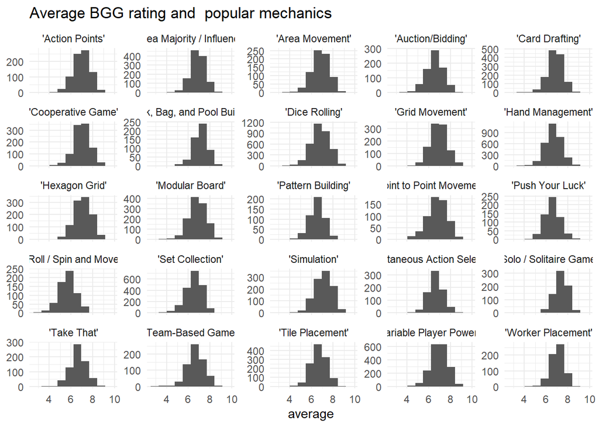

```r
bgames %>%
  filter(users_rated >= 100, !is.na(boardgamemechanic)) %>%
  mutate(boardgamemechanic = str_extract_all(boardgamemechanic, "\'([^\']*)\'")) %>%
  unnest_longer(boardgamemechanic) %>%
  filter(boardgamemechanic %in% pop_mechanic) %>%
  ggplot(aes(average)) +
  geom_histogram(bins=10) +
  facet_wrap(~boardgamemechanic, scales = "free_y") +
  theme_minimal() +
  theme(axis.title.y = element_blank()) +
  labs(title = "Average BGG rating and  popular mechanics")
```

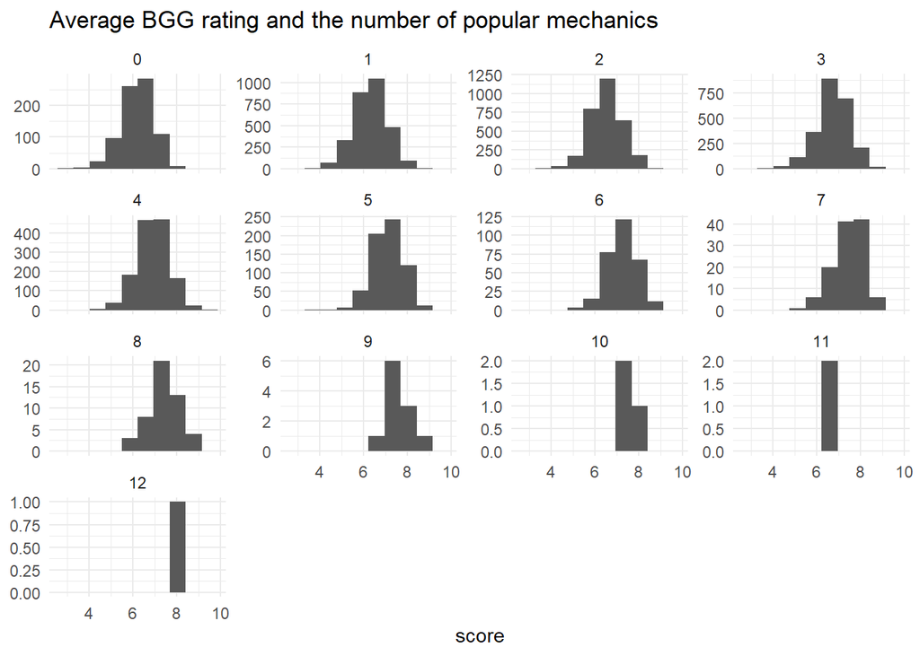

```r
bgames %>%
  filter(users_rated >= 100, !is.na(boardgamemechanic)) %>%
  mutate(boardgamemechanic = str_extract_all(boardgamemechanic, "\'([^\']*)\'")) %>%
  unnest_longer(boardgamemechanic) %>%
  mutate(mech_pop = ifelse(boardgamemechanic %in% pop_mechanic, 1, 0)) %>%
  group_by(id) %>%
  summarise(score = mean(average), n_popular = sum(mech_pop)) %>%
  ggplot(aes(score)) +
  geom_histogram(bins=10) +
  facet_wrap(~n_popular, scales = "free_y") +
  theme_minimal() +
  theme(axis.title.y = element_blank()) +
  labs(title = "Average BGG rating and the number of popular mechanics")
```

Most mechanics don’t effect score distributions, however the number of popular mechanics do effect them.

Now do the same for popular categories

```r
#Keep popular categories in a vector for easier use later
pop_categ <- bgames %>%
  filter(users_rated >= 100, !is.na(boardgamecategory)) %>%
  mutate(boardgamecategory = str_extract_all(boardgamecategory, "\'([^\']*)\'")) %>%
  unnest_longer(boardgamecategory) %>%
  count(boardgamecategory) %>%
  slice_max(order_by = n, n = 15) %>%
  pull(boardgamecategory)
pop_categ
```

```
##  [1] "'Card Game'"         "'Wargame'"           "'Fantasy'"
##  [4] "'Fighting'"          "'Science Fiction'"   "'Economic'"
##  [7] "'Dice'"              "'Party Game'"        "'Animals'"
## [10] "'Abstract Strategy'" "'Adventure'"         "'Bluffing'"
## [13] "'Deduction'"         "'Miniatures'"        "'Medieval'"
```

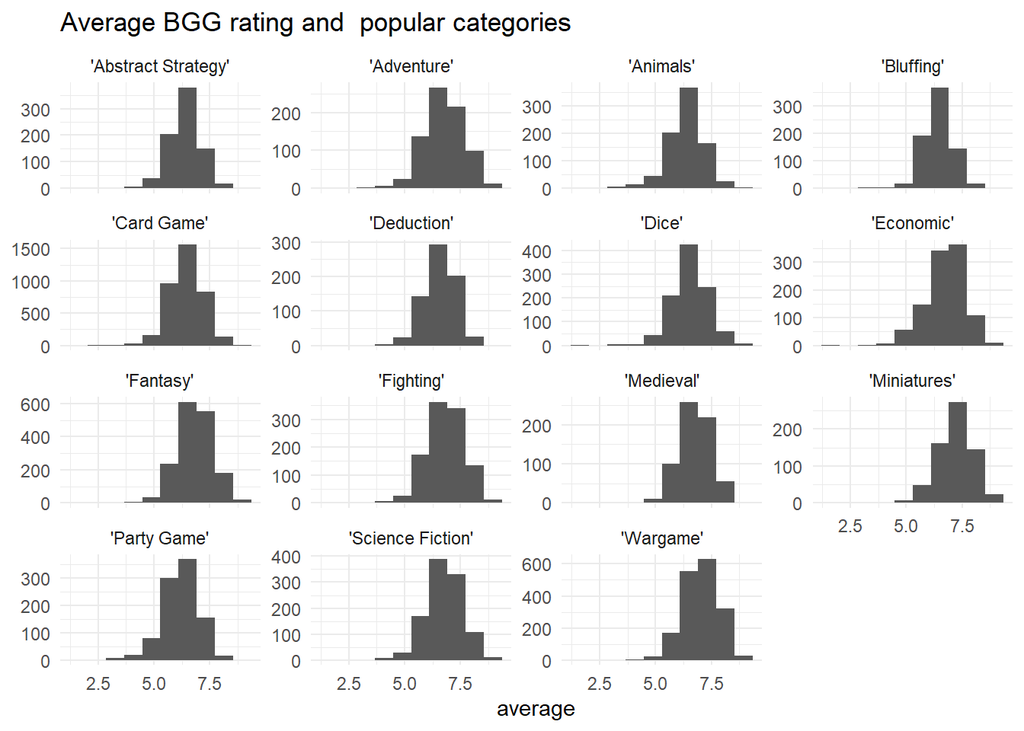

```r
bgames %>%
  filter(users_rated >= 100, !is.na(boardgamecategory)) %>%
  mutate(boardgamecategory = str_extract_all(boardgamecategory, "\'([^\']*)\'")) %>%
  unnest_longer(boardgamecategory) %>%
  filter(boardgamecategory %in% pop_categ) %>%
  ggplot(aes(average)) +
  geom_histogram(bins=10) +
  facet_wrap(~boardgamecategory, scales = "free_y") +
  theme_minimal() +
  theme(axis.title.y = element_blank()) +
  labs(title = "Average BGG rating and  popular categories")
```

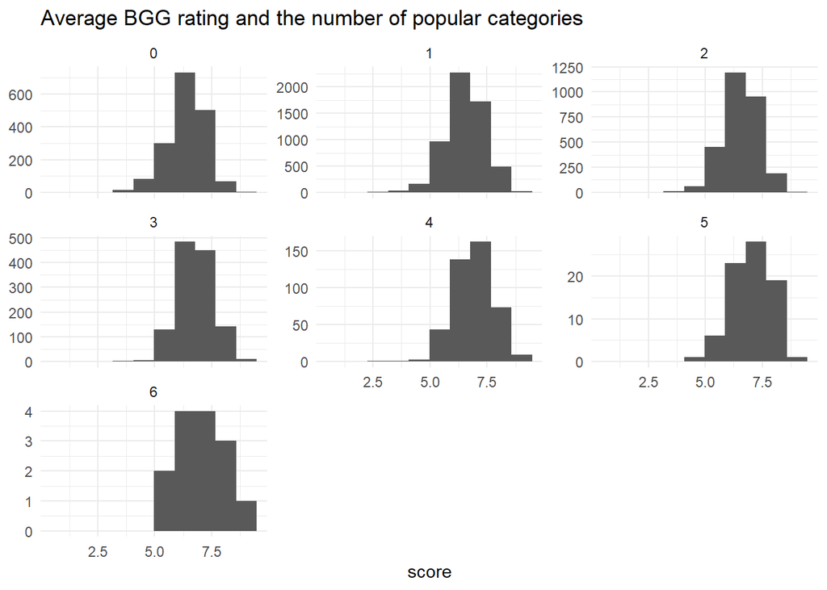

```r
bgames %>%
  filter(users_rated >= 100, !is.na(boardgamecategory)) %>%
  mutate(boardgamecategory = str_extract_all(boardgamecategory,
                                             "\'([^\']*)\'")) %>%
  unnest_longer(boardgamecategory) %>%
  mutate(categ_pop = ifelse(boardgamecategory %in% pop_categ, 1, 0)) %>%
  group_by(id) %>%
  summarise(score = mean(average), n_popular = sum(categ_pop)) %>%
  ggplot(aes(score)) +
  geom_histogram(bins=10) +
  facet_wrap(~n_popular, scales = "free_y") +
  theme_minimal() +
  theme(axis.title.y = element_blank()) +
  labs(title = "Average BGG rating and the number of popular categories")
```

Most categories don’t effect score distributions, however the number of popular categories do effect them.

## Other possible predictors

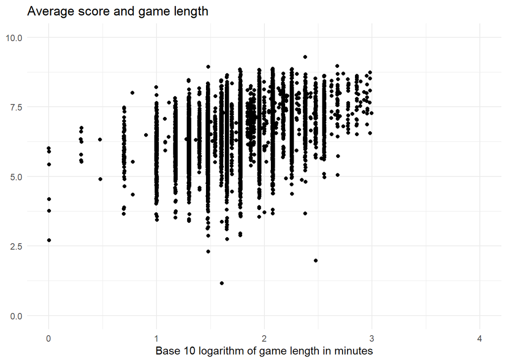

```r
bgames %>%
  #Remove games that take up close to a day or more time
  #Also remove games shorter than a minute
  filter(playingtime < 1000, users_rated >= 100,
         playingtime >= 1) %>%
  ggplot(aes(log10(playingtime), average)) +
  geom_jitter() +
  theme_minimal() +
  theme(axis.title.y = element_blank()) +
  labs(title = "Average score and game length") +
  xlab(label = "Base 10 logarithm of game length in minutes") +
  scale_x_continuous(limits = c(0, 4)) +
  scale_y_continuous(limits = c(0, 10))
```

Interestingly higher scored games tend to be longer

See if minimum player count could effect scores.

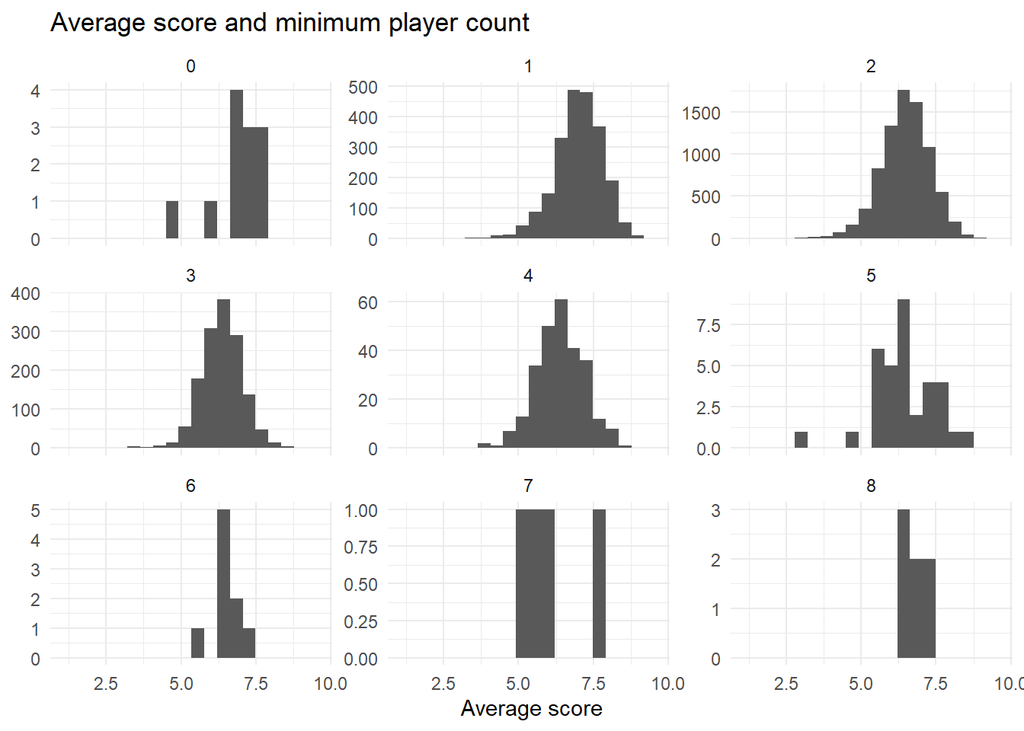

```r
bgames %>%
  filter(playingtime < 1000, users_rated >= 100) %>%
  ggplot(aes(average)) +
  geom_histogram(bins = 20) +
  facet_wrap(~minplayers, scales = "free_y") +
  theme_minimal() +
  theme(axis.title.y = element_blank()) +
  labs(title = "Average score and minimum player count") +
  xlab(label = "Average score")
```

They don’t seem to significantly change scores.

See if the minimum age has some connection with scores

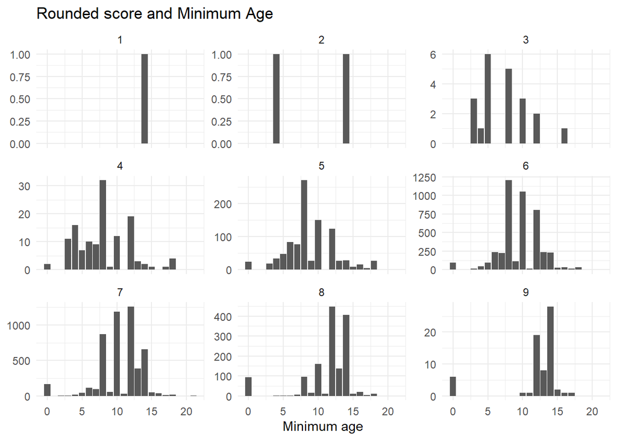

```r
bgames %>%
  filter(playingtime < 1000, users_rated >= 100) %>%
  mutate(score = round(average)) %>%
  ggplot(aes(minage)) +
  geom_bar() +
  facet_wrap(~score, scales = "free_y") +
  theme_minimal() +
  theme(axis.title.y = element_blank()) +
  labs(title = "Rounded score and Minimum Age") +
  xlab(label = "Minimum age")
```

There is no evident connection between these variables, but it still might be worthwile to check out the effect of minimum age using statistics later.

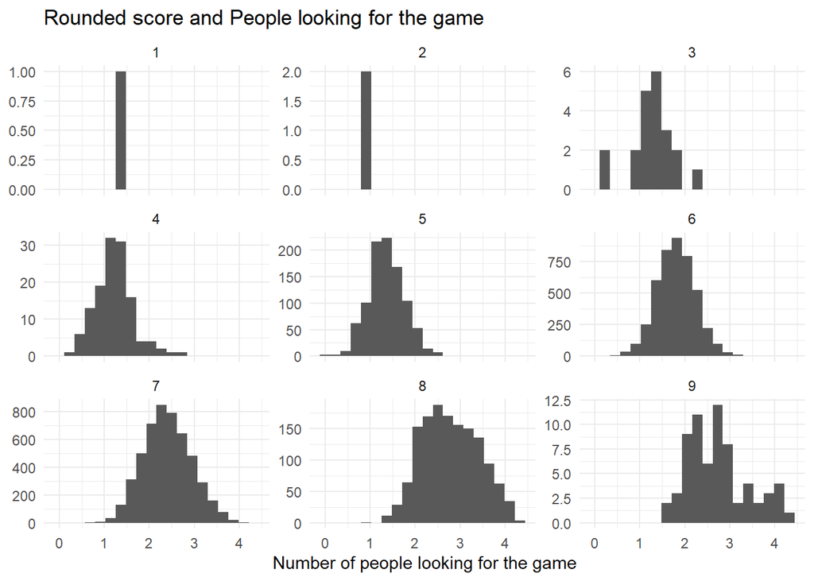

```r
bgames %>%
  filter(playingtime < 1000, users_rated >= 100) %>%
  mutate(score = round(average),
         #Want and wish mean basically the same: the given person wants to own the game
         need = wanting + wishing) %>%
  ggplot(aes(log10(need))) +
  geom_histogram(bins = 20) +
  facet_wrap(~score, scales = "free_y") +
  theme_minimal() +
  theme(axis.title.y = element_blank()) +
  labs(title = "Rounded score and People looking for the game") +
  xlab(label = "Number of people looking for the game")
```

Clearly more people want to own higher scored games. It seems tempting to use this variable in the estimation of scores, however it’s probably the other way around, and higher scores lead to a higher number of people wanting the game.

# Create a cleaner tibble for modelbuilding

I will implement some useful modifications to make it easier to test hypotheses. I will create a popular mechanic and a popular category variable to see how well the games match these. I will also filter out too short, too long games and games with too few ratings. I will also remove games which were made before 1990, the approximate beggining of modern board games. I will also check if artist or designers have a big effect, from them the top 5 will be kept, the others will be put into an Other factor.

First get how many popular categories and mechanics are there in different games

```r
categ_pop_num <-  bgames %>%
  mutate(boardgamecategory = str_extract_all(boardgamecategory,
                                             "\'([^\']*)\'")) %>%
  unnest_longer(boardgamecategory) %>%
  mutate(categ_pop = ifelse(boardgamecategory %in% pop_categ, 1, 0),
         ) %>%
  group_by(id) %>%
  summarise(categ_pop = sum(categ_pop)) %>%
  filter(!is.na(categ_pop))


mech_pop_num <- bgames %>%
  mutate(boardgamemechanic = str_extract_all(boardgamemechanic,
                                             "\'([^\']*)\'")) %>%
  unnest_longer(boardgamemechanic) %>%
  mutate(mech_pop = ifelse(boardgamemechanic %in% pop_mechanic, 1, 0)) %>%
  group_by(id) %>%
  summarise(mech_pop = sum(mech_pop)) %>%
  filter(!is.na(mech_pop))
```

```r
bgg <- bgames %>%
  left_join(categ_pop_num, by = "id") %>%
  left_join(mech_pop_num, by = "id") %>%
  filter(playingtime < 1000,
         users_rated >= 100,
         playingtime >= 1,
         yearpublished >= 1990,
         yearpublished <= 2022,
         !is.na(boardgamecategory),
         !is.na(boardgamemechanic),
         !is.na(minage),
         !is.na(yearpublished),
         !is.na(playingtime),
         !is.na(boardgamedesigner),
         !is.na(boardgameartist),
         !is.na(average)) %>%
  select(id, yearpublished, minplayers,
         playingtime, minage, boardgamedesigner,
         boardgameartist, wanting, wishing, average,
         categ_pop, mech_pop) %>%
  mutate(boardgamedesigner =  fct_lump_n(boardgamedesigner, n= 6),
         boardgameartist = fct_lump_n(boardgameartist, n = 6)
         ) %>%
  mutate(boardgamedesigner = fct_other(boardgamedesigner,
                                      drop = c("['(Uncredited)']")),
         boardgameartist = fct_other(boardgameartist,
                                      drop = c("['(Uncredited)']")),
         n_need = wanting + wishing,
         #modify years to start at 0, this makes it more useable for the regression, interpretation is: how many years passed sincs 1990 to the making of this game
         yearpublished = yearpublished - min(yearpublished)) %>%
  mutate(boardgamedesigner = fct_infreq(boardgamedesigner),
         boardgameartist = fct_infreq(boardgameartist))
```

# Statistical model for average game scores

I think that minimum age, Publishing year, Game length, number of popular mechanics and categories, and the person of the designer/artist could have an effect on the BGG scores of boardgames. Here i will test this using a linear regression.

```r
bgg_model <- lm(average ~ yearpublished + minage +
                          I(log10(playingtime)) +
                          boardgamedesigner +
                          boardgameartist +
                          categ_pop +
                          mech_pop,
                data = bgg)

null_model <- lm(average ~ 1,
                 data = bgg_model$model)
```

Compare the model to the null

```r
AIC(null_model)
```

```
## [1] 19016.23
```

```r
AIC(bgg_model)
```

```
## [1] 15100.32
```

```r
anova(null_model, bgg_model)
```

```
## Analysis of Variance Table
##
## Model 1: average ~ 1
## Model 2: average ~ yearpublished + minage + I(log10(playingtime)) + boardgamedesigner +
##     boardgameartist + categ_pop + mech_pop
##   Res.Df    RSS Df Sum of Sq      F    Pr(>F)
## 1   8506 4654.8
## 2   8491 2927.2 15    1727.6 334.08 < 2.2e-16 ***
## ---
## Signif. codes:  0 '***' 0.001 '**' 0.01 '*' 0.05 '.' 0.1 ' ' 1
```

Based on the F test and the AIC scores the more complex model is better at describing the data.

```r
r2(bgg_model)
```

```
## # R2 for Linear Regression
##        R2: 0.371
##   adj. R2: 0.370
```

The R-squared indicates that the predictive power of the model could be furthe improved

See coefficients:

```r
tidy(bgg_model) %>%
  DT::datatable(
  extensions = 'FixedColumns',
  options = list(
    scrollX = TRUE,
    fixedColumns = TRUE
  )
)
```

|  | term | estimate | std.error | statistic | p.value |
| --- | --- | --- | --- | --- | --- |
| 1 | (Intercept) | 4.21967530317823 | 0.0408183077744706 | 103.377026957923 | 0 |
| 2 | yearpublished | 0.0369009328092816 | 0.000931832239550369 | 39.6004036381991 | 7.14310771e-315 |
| 3 | minage | 0.00372067360960993 | 0.00228167694855132 | 1.63067502258471 | 0.102995998312754 |
| 4 | I(log10(playingtime)) | 0.854702758482434 | 0.0201819142830913 | 42.349935020709 | 0 |
| 5 | boardgamedesigner['Reiner Knizia'] | 0.0834321756584192 | 0.0420940010464083 | 1.98204431948476 | 0.0475064696242906 |
| 6 | boardgamedesigner['Martin Wallace'] | -0.058935610664417 | 0.0716921989029538 | -0.822064486321521 | 0.411063279167382 |
| 7 | boardgamedesigner['Michael Schacht'] | -0.0319207356187118 | 0.0811671787704799 | -0.393271468865211 | 0.694128862235792 |
| 8 | boardgamedesigner['Friedemann Friese'] | 0.135811054505504 | 0.0874065215883516 | 1.55378628548013 | 0.120272672286767 |
| 9 | boardgamedesigner['Klaus Teuber'] | 0.111517238281733 | 0.0865510697784268 | 1.28845592050127 | 0.197622410058106 |
| 10 | boardgameartist['Franz Vohwinkel'] | -0.0237100852726665 | 0.0506467238465648 | -0.468146475663395 | 0.639691861629833 |

[output cut: 6 more lines]

All theorized variebles have a significant effect, except minimum age. Year, Playing time, number of popular mechanics and categories increase the score. Among designers only Reiner Knizia has a significant effect and his scores are higher. That is he makes a great amount of popular games. Among artists only Harald Lieske has a significant effect, but he decreases scores. That is if a game had art made by him it has probably lower scores.

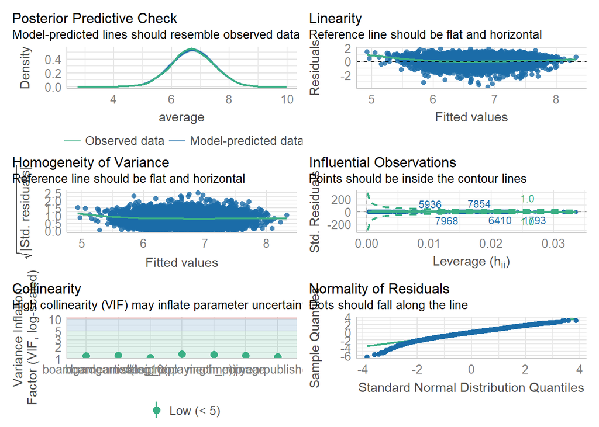

```r
check_model(bgg_model)
```

The model seems adequate. Checks are right and there is no great outlier. Linearity is not the best, but mostly acceptable.

Based on this, if one wants to make a high scoring game they have to make it as long as possible, release it as late as possible, put in as many popular mechanics as possible, fuse as many popular categories as possible, hire Reiner Knizia, and avoid hiring Harald Lieske. This is of course, a joke. But mechanics and categories can really become popular and copied by others wanting success.